# Booksales

```python
#Get to know working directory

import os
os.getcwd()
```

```
'C:\\Users\\jeanj'
```

```python
#Change the working directory to my preferred location

new_path=r'D:\Python\Book sales project'
os.chdir(new_path)
print("Current working directory",os.getcwd())
```

```
Current working directory D:\Python\Book sales project
```

```python
#Import all required libraries for this project

import pandas as pd
import matplotlib.pyplot as plt
import numpy as np
import seaborn as sns
```

```python
## Load the dataset and have a glimpse

df = pd.read_csv("Books_data.csv")
df.head()
```

|  | index | Publishing Year | Book Name | Author | language_code | Author_Rating | Book_average_rating | Book_ratings_count | genre | gross sales | publisher revenue | sale price | sales rank | Publisher | units sold |
| --- | --- | --- | --- | --- | --- | --- | --- | --- | --- | --- | --- | --- | --- | --- | --- |
| 0 | 0 | 1975.0 | Beowulf | Unknown, Seamus Heaney | en-US | Novice | 3.42 | 155903 | genre fiction | 34160.0 | 20496.0 | 4.88 | 1 | HarperCollins Publishers | 7000 |
| 1 | 1 | 1987.0 | Batman: Year One | Frank Miller, David Mazzucchelli, Richmond Lew... | eng | Intermediate | 4.23 | 145267 | genre fiction | 12437.5 | 7462.5 | 1.99 | 2 | HarperCollins Publishers | 6250 |
| 2 | 2 | 2015.0 | Go Set a Watchman | Harper Lee | eng | Novice | 3.31 | 138669 | genre fiction | 47795.0 | 28677.0 | 8.69 | 3 | Amazon Digital Services, Inc. | 5500 |
| 3 | 3 | 2008.0 | When You Are Engulfed in Flames | David Sedaris | en-US | Intermediate | 4.04 | 150898 | fiction | 41250.0 | 24750.0 | 7.50 | 3 | Hachette Book Group | 5500 |
| 4 | 4 | 2011.0 | Daughter of Smoke & Bone | Laini Taylor | eng | Intermediate | 4.04 | 198283 | genre fiction | 37952.5 | 22771.5 | 7.99 | 4 | Penguin Group (USA) LLC | 4750 |

```python
# Summary of the dataset to understand the data
df.describe()
```

[output not shown]

```python
#Fix the negative value under Publishing Year by creating a new filtered dataframe

df = df[df["Publishing Year"] > 1900]
```

```python
#Check for missing values in the rows for each column and add the total missing values
df.isna().sum()
```

```
index                   0
Publishing Year         0
Book Name               0
Author                  0
language_code          47
Author_Rating           0
Book_average_rating     0
Book_ratings_count      0
genre                   0
gross sales             0
publisher revenue       0
sale price              0
sales rank              0
Publisher               0
units sold              0
dtype: int64
```

```python
#Drop the missing book names and change the original dataset

df.dropna(subset=["Book Name"],inplace= True)
```

```python
#Get the count of duplicated rows (Clearly, there are no duplicates)

df.duplicated().sum()
```

```
0
```

```python
#Check for unique values in each column
df.nunique()
```

```
index                  988
Publishing Year        101
Book Name              987
Author                 669
language_code            8
Author_Rating            4
Book_average_rating    133
Book_ratings_count     983
genre                    4
gross sales            774
publisher revenue      570
sale price             143
sales rank             818
Publisher                9
units sold             470
dtype: int64
```

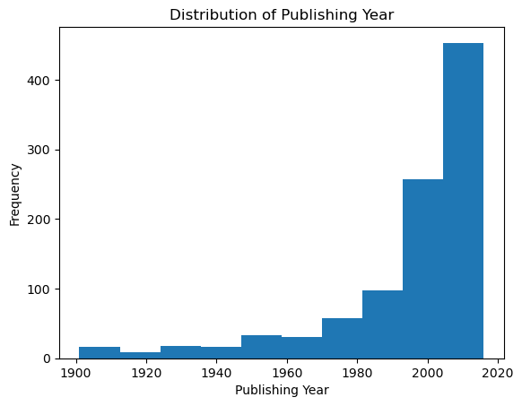

```python
#Look at the distribution of the publishing year

plt.hist(df["Publishing Year"])
plt.xlabel("Publishing Year")
plt.ylabel("Frequency")
plt.title("Distribution of Publishing Year")
plt.show()
```

#### Figure (i): The histogram above reveals a significant increase in book publications after 1980, with a noticeable surge starting from the year 2000. The highest concentration of publishing activity occurs between 2000 and 2020, indicating that the majority of books in the dataset are relatively recent. This trend highlights a modern publishing boom in the 21st century.

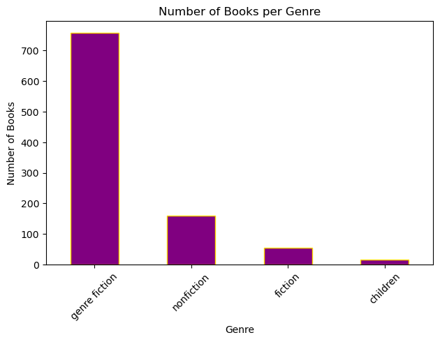

```python
#No. of books by Genre

df["genre"].value_counts().plot(kind="bar", color="purple", edgecolor="gold")
plt.xlabel("Genre")
plt.ylabel("Number of Books")
plt.title("Number of Books per Genre")
plt.show()
```

```python
#Group by Author (What is the average number of ratings per book for each author?)

df.groupby("Author")["Book_average_rating"].mean().sort_values(ascending=False)
```

```
Author
Bill Watterson                  4.650000
Bill Watterson, G.B. Trudeau    4.610000
J.R.R. Tolkien                  4.590000
George R.R. Martin              4.560000
Sarah J. Maas                   4.526000
                                  ...
Chetan Bhagat                   3.273333
Audrey Niffenegger              3.230000
Herman Koch, Sam Garrett        3.220000
P.D. James                      3.210000
Sue Monk Kidd                   3.100000
Name: Book_average_rating, Length: 669, dtype: float64
```

#### The author Bill Watterson has the highest average ratings in comparison to the other authors.

```python
df.groupby("genre")["Book_ratings_count"].count().sort_values(ascending=False)
```

```
genre
genre fiction    759
nonfiction       160
fiction           54
children          15
Name: Book_ratings_count, dtype: int64
```

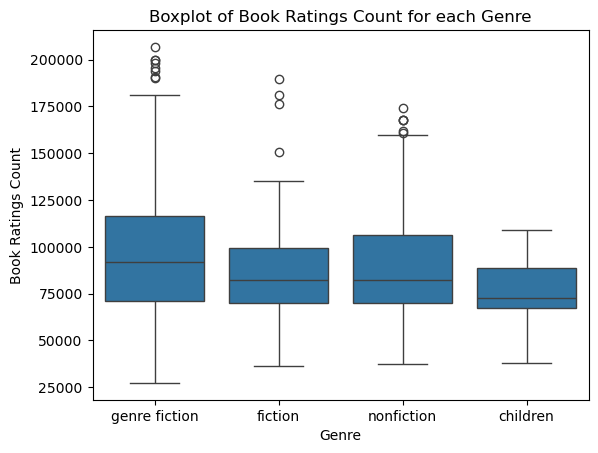

```python
#Boxplot of Book ratings count for each genre
sns.boxplot(x = "genre", y="Book_ratings_count", data = df)
plt.xlabel("Genre")
plt.ylabel("Book Ratings Count")
plt.title("Boxplot of Book Ratings Count for each Genre")
plt.show()
```

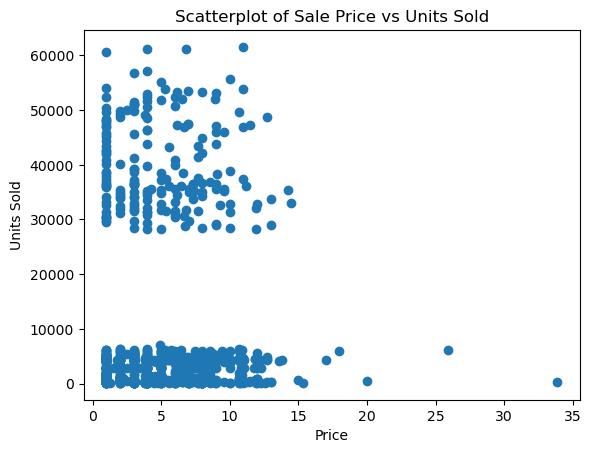

```python
#Scatterplot of sale price and units sold

plt.scatter(x="sale price", y="units sold", data = df)
plt.xlabel("Price")
plt.ylabel("Units Sold")
plt.title("Scatterplot of Sale Price vs Units Sold")
plt.show()
```

#### Figure (iv): This scatterplot examines the relationship between sale price and units sold. It shows that books with higher sale prices tend to have fewer units sold, while books with lower sale prices generally experience higher sales volumes, aligning with typical market behavior where more affordable books sell in greater quantities. However, there are also some exceptions, as certain books with higher prices still sold fewer units, highlighting outliers in the data.

```python
#Distribution of the Language Code (Count)

language_count=df["language_code"].value_counts()
```

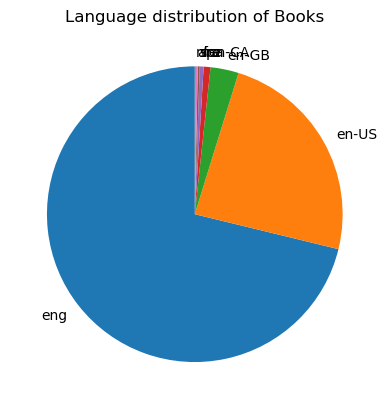

```python
plt.pie(language_count, labels = language_count.index,startangle=90)
plt.title("Language distribution of Books")
plt.show()
```

#### Figure (v): This pie chart illustrates the distribution of books by language. It shows that English is the most common language among the books in the dataset, occupying the largest portion of the chart. This indicates that a significant majority of the books are written in English, highlighting its dominance in the collection.

```python
df.columns
```

```
Index(['index', 'Publishing Year', 'Book Name', 'Author', 'language_code',
       'Author_Rating', 'Book_average_rating', 'Book_ratings_count', 'genre',
       'gross sales', 'publisher revenue', 'sale price', 'sales rank',
       'Publisher ', 'units sold'],
      dtype='object')
```

```python
#What is the total revenue for each publisher?

df.groupby("Publisher ")["publisher revenue"].sum().sort_values(ascending=False)
```

```
Publisher
Penguin Group (USA) LLC                 191581.104
Random House LLC                        174956.244
Amazon Digital Services,  Inc.          141767.772
HarperCollins Publishers                121769.814
Hachette Book Group                     107410.968
Simon and Schuster Digital Sales Inc     46858.206
Macmillan                                31249.830
HarperCollins Publishing                  2830.806
HarperCollins Christian Publishing        2135.670
Name: publisher revenue, dtype: float64
```

```python
#What is the average books rating count for each author rating?
df.groupby("Author_Rating")["Book_ratings_count"].mean().sort_values(ascending=False)
```

```
Author_Rating
Intermediate    101400.272569
Famous           98295.250000
Novice           87318.464286
Excellent        83804.800595
Name: Book_ratings_count, dtype: float64
```

```python
#What is the count of books per language?
df.groupby("language_code").size().sort_values(ascending=False)
```

```
language_code
eng      670
en-US    226
en-GB     29
en-CA      7
fre        4
ara        2
spa        2
nl         1
dtype: int64
```

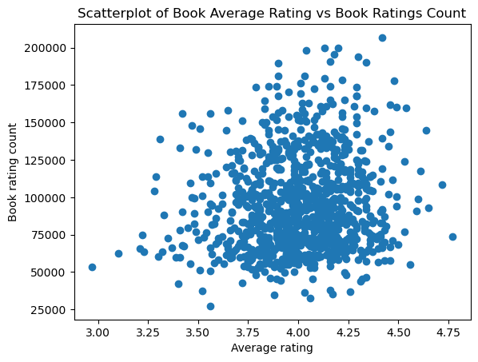

```python
#Distribution of AuthorRating and Book Ratings Count

plt.scatter(df["Book_average_rating"],df["Book_ratings_count"])
plt.xlabel("Average rating")
plt.ylabel("Book rating count")
plt.title("Scatterplot of Book Average Rating vs Book Ratings Count")
plt.show()
```

#### Figure (vi): The scatterplot examines the relationship between Average Rating and Book Rating Count. It reveals that, on average, books with rating counts between 50,000 and 150,000 tend to cluster around an average rating of 3.75 to 4.25. This suggests that books with a moderate number of ratings generally receive favorable average ratings, indicating consistent reader satisfaction within this range.

```python
#Barchart of the gross sales for each author

Gross_sales_per_author= df.groupby("Author")["gross sales"].sum().sort_values(ascending=False).head(10)
Gross_sales_per_author
```

```
Author
Harper Lee                47795.00
Stephen King              43322.65
David Sedaris             42323.41
Charlaine Harris          39453.08
Laini Taylor              38278.41
Unknown, Seamus Heaney    34160.00
Sarah Dessen              31034.85
Colleen Hoover            29706.14
C.S. Lewis                28972.57
Jeffrey Eugenides         27984.38
Name: gross sales, dtype: float64
```

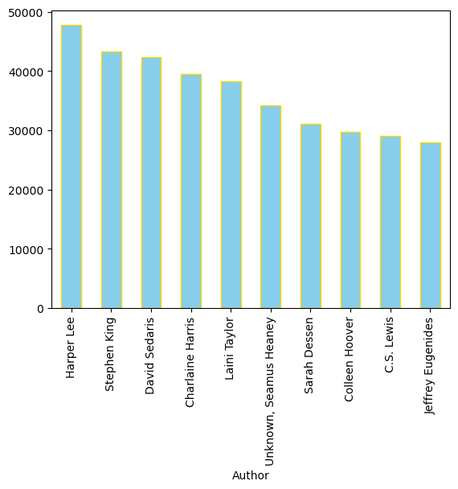

```python
Gross_sales_per_author.plot(kind="bar", color="skyblue",edgecolor="gold")
```

#### Figure (vii):This bar chart presents the total gross sales attributed to the top 10 authors. Each bar represents an individual author, allowing for a clear comparison of their commercial success. The chart highlights which authors generated the highest sales, offering insights into the most financially successful contributors in the dataset.

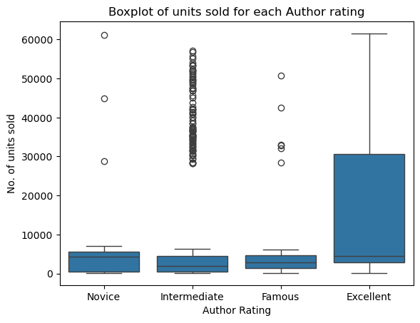

```python
#Boxplot for units sold each author rating

sns.boxplot(x="Author_Rating",y ="units sold", data=df)
plt.xlabel("Author Rating")
plt.ylabel("No. of units sold")
plt.title("Boxplot of units sold for each Author rating")
plt.show()
```

#### Figure (viii): The boxplot above illustrates the distribution of units sold across different author rating categories: Novice, Intermediate, Famous, and Excellent. The Excellent author rating category shows the highest median number of units sold, suggesting that authors in this category tend to achieve better sales performance overall. It also has a much larger IQR, indicating greater variability in sales among these authors—some may sell moderately, while others achieve exceptionally high figures.n contrast, the Novice, Intermediate, and Famous categories show lower medians and smaller IQRs, suggesting more consistent but generally lower sales figures. Additionally, these three categories display several outliers, indicating the presence of books that sold significantly more than the majority within their respective groups.This highlights a positive relationship between author rating and sales performance, while also emphasizing variability and standout cases through the distribution spread and outliers.

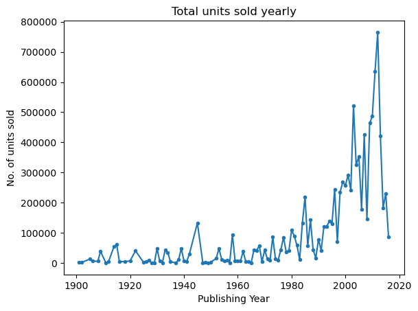

```python
#Line chart of publishing year and units sold

df.groupby("Publishing Year")["units sold"].sum().plot(kind="line",marker=".")
plt.xlabel("Publishing Year")
plt.ylabel("No. of units sold")
plt.title("Total units sold yearly")
plt.show()
```

#### Figure (ix): The line chart illustrates the total number of units sold per publishing year. From 1900 to 1980, the trend appears relatively stable, with a slight surge observed around 1940. A period of notable growth in units sold begins around 1980, continuing steadily up to approximately 2010. After this peak, the chart shows a decline in units sold leading up to the year 2020. This pattern suggests an increase in book sales during the late 20th century and early 21st century, followed by a potential slowdown in more recent years.